# Praca domowa 2

Kamila Więckowska

## Dane

Dane wykorzystane w Pracy domowej 2 opisują wycenę nieruchmości. Każda obserwacja jest pewną nieruchmością, która posiada informacje takie jak powierzchnia, liczba pokoi, liczba łazienek i wiele więcj. Opis wszystkich kolumn w pliku `README.md`.

## Zadanie 1

Jak wygląda rozkład ceny nieruchomości w poszczególnych kodach pocztowych na przestrzeni lat? Rozważamy kody pocztowe, które mają więcej niż 280 posiadłości.

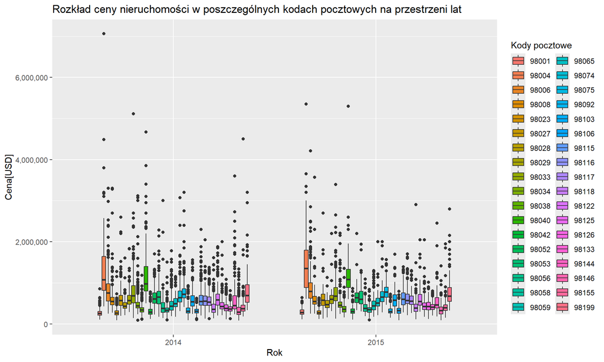

```r
# Tu umieść kod do wygenerowania odpowiedzi do zadania.

zipcodes <- df %>%
  group_by(zipcode) %>%
  summarise(count = n(), .groups = 'drop') %>%
  filter(count > 280)


df %>%
  filter(zipcode %in% zipcodes$zipcode) %>%
  mutate(date = strptime(date, format="%Y%m%dT%H%M%S")) %>%
  mutate(year = as.integer(format(date, '%Y'))) %>%
  ggplot(aes(x = as.factor(year), y = price, fill = as.factor(zipcode)))+
  labs(x = 'Rok',
       y = 'Cena[USD]',
       title = 'Rozkład ceny nieruchomości w poszczególnych kodach pocztowych na przestrzeni lat',
       fill = 'Kody pocztowe')+
  geom_boxplot()+
  scale_y_continuous(labels = scales::comma)
```

**Komentarz: Na wykresie widać znaczące zróżnicowanie cen nieruchomości w różnych kodach pocztowych. Na przestrzeni lat, posiadłości w poszczególnych kodach pocztowych prezentowały zbliżony zakres cen, typowy dla danego obszaru. Jedynie w niektórych przypadkach występowały wartości odbiegające od tej normy. Warto zauważyć, że w 2015 roku te wyjątki wskazywały na niższe ceny niż w roku poprzednim.**

## Zadanie 2

Czy jest różnica w rozkładzie ceny nierchomości od powierzchni mieszkalnej uwzględniając podział na nieruchomości z piwnicą i bez?

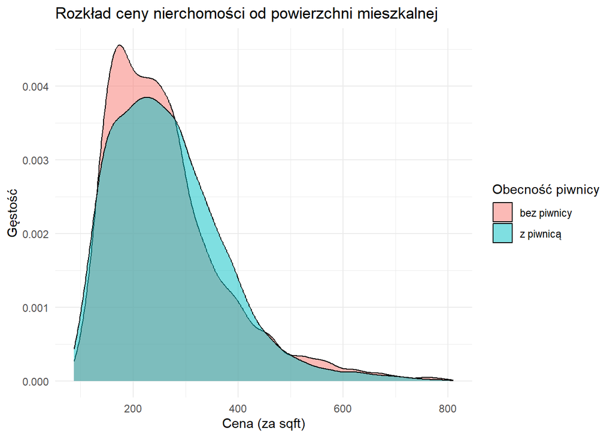

```r
# Tu umieść kod do wygenerowania odpowiedzi do zadania.

df %>%
  mutate(price_for_sqft = price / sqft_living,
         has_basement = ifelse(sqft_basement > 0, 'z piwnicą', 'bez piwnicy')) %>%
  ggplot(aes(x = price_for_sqft, fill = has_basement)) +
  geom_density(alpha = 0.5) +
  labs(title =  "Rozkład ceny nierchomości od powierzchni mieszkalnej",x = "Cena (za sqft)", y = 'Gęstość', fill = "Obecność piwnicy") +
  theme_minimal()
```

**Komentarz: Oba typy nieruchomości charakteryzują się podobnym rozkładem cen w zależności od powierzchni. W analizowanych danych dominują budynki, których cena wynosi od 150 do 300 dolarów za stopę kwadratową. Występują również droższe posiadłości, jednak analiza wykresu wskazuje na to, że po osiągnięciu określonego punktu, w którym następuje największe zagęszczenie nieruchomości, wraz ze wzrostem ceny maleje częstość ich występowania. W przypadku najczęściej występującej ceny budynków w przedziale 150-300 dolarów za stopę kwadratową, większa liczba nieruchomości nie ma piwnicy. Jednak w miarę wzrostu ceny zaczynają dominować posiadłości z piwnicą. Przy najwyższych wartościach ceny nieruchomości za stopę kwadratową, gęstość występowania budynków z piwnicą i bez staje się zbliżona.**

## Zadanie 3

Jaka jest zależność pomiędzy jakością wykończenia nieruchomości a liczbą pięter?

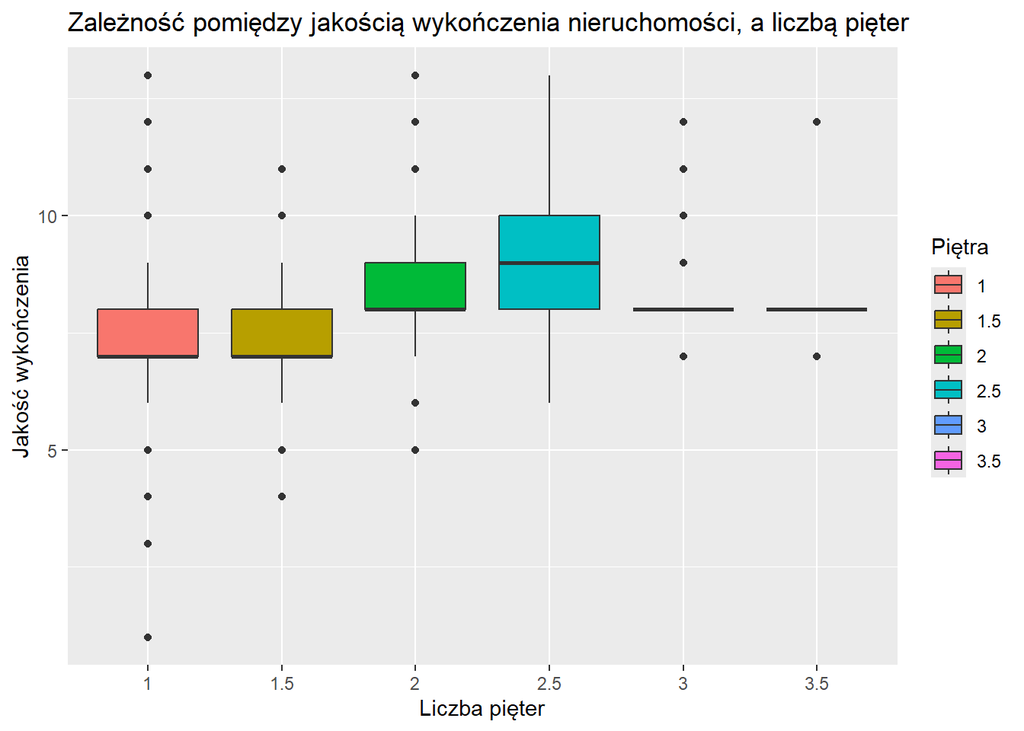

```r
# Tu umieść kod do wygenerowania odpowiedzi do zadania.

df %>%
  ggplot(aes(x = as.factor(floors), y = grade, fill = as.factor(floors))) +
  geom_boxplot()+
  labs(title = "Zależność pomiędzy jakością wykończenia nieruchomości, a liczbą pięter", x = "Liczba pięter", y = "Jakość wykończenia", fill = 'Piętra')
```

**Komentarz: Jakość wykończenia dla domów o liczbie pięter 1 i 1.5 jest do siebie zbliżona. Obie grupy mają takie same mediany i większość danych jest w zbliżonym do siebie zakresie wartości jakości wykończenia. Można zauważyć, że jakość wykończenia wzrasta dla kolejnych 2 liczb pięter. Dla domów mających 2.5 poziomów, jakość wykończenia jest największa spośród wszystkich grup. Standard wykończenia dla budowli o 3 i 3.5 piętrach jest bardzo podobny. Widać jednak, że mediana jest niższa niż dla poprzedniej grupy. Jednak nie jest to taki spadek, jak ten między 1 a 4 grupą. Nieruchomości o mniejszej liczbie pięter (1-2), mają bardziej zróżnicowane wartości jakości wykończenia, niż te o większej liczbie poziomów. Podsumowując, standard wykończenia raczej zwiększa się z liczbą pięter, jednak najlepszą jakość mają budynki o 2.5 poziomach.**

## Zadanie 4

Jaka jest zależność między powierzchnią mieszkalną nieruchomości a powierzchnią gruntu w podziale na liczbę sypialni?

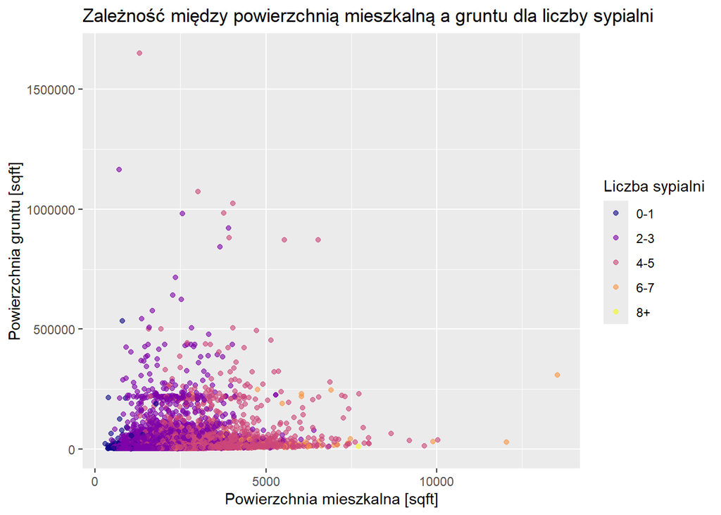

```r
# Tu umieść kod do wygenerowania odpowiedzi do zadania.

df %>%
  mutate(bedroom_gr = case_when(bedrooms <= 1 ~ "0-1", bedrooms <= 3 ~ "2-3", bedrooms <= 5 ~ "4-5", bedrooms <= 7 ~ "6-7", bedrooms > 7 ~ "8+")) %>%
  ggplot(aes(x = sqft_living, y = sqft_lot, color = as.factor(bedroom_gr))) +
  geom_point(alpha = 0.6) +
  scale_color_viridis_d(option = "plasma") +
  labs(title = "Zależność między powierzchnią mieszkalną a gruntu dla liczby sypialni",
       x = "Powierzchnia mieszkalna [sqft]",
       y = "Powierzchnia gruntu [sqft]",
       color = "Liczba sypialni")
```

**Komentarz: Na wykresie jest duże zagęszczenie punktów na przy osi x, co oznacza że w naszej grupie danych dominują nieruchomości z mniejszą powierzchnią gruntu. Dla domów, które mają 0-1 sypialni nie ma dużej zależności między powierzchnią mieszkalną a gruntu. Obie powierzchnie są znacznie mniejsze niż wartości innych grup nieruchomości. Dla posiadłości mających 2-3 sypialni możemy zauważyć, że domy o średniej wartości powierzchni mieszkalnej mają raczej większą powierzchnię gruntową. Tą samą zależność można zaobserwować dla grupy o 3-4 sypialniach. Dla ostatnich grup zależności są niewielkie. Grupa 8+ ma delikatną tendencje do wzrastania wraz z obydwiema zmiennymi, jednak nie można tu jednoznacznie stwierdzić tej zależności. Dużą zależność natomiast widać w wielkości powierzchni mieszkalnej, a liczbie sypialni. Wraz z większą ilością tych pokoi wzrasta metraż użytkowy. Jednak największe powierzchnie gruntu mają nieruchomości z raczej mniejszą ilością pokoi(2-3, 4-5).**

## Zadanie 5

Rozważmy tylko nieruchomości, które miały remont. W której dekadzie było najwięcej przeprowadzonych remontów? Czy w poszczególnych dekadach jest porównywalny procent nieruchmości dla każdej wartości miary jakości i wykończenia nieruchomości?

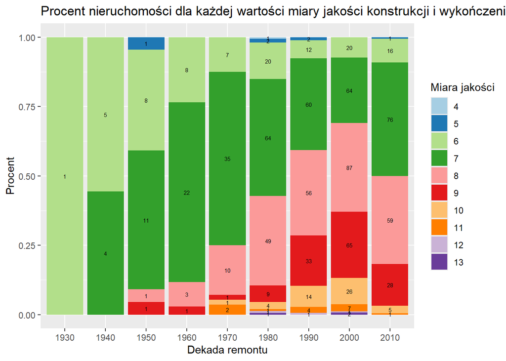

```r
# Tu umieść kod do wygenerowania odpowiedzi do zadania.

df_renovated <- df %>%
  filter(yr_renovated > 0 ) %>%
  mutate(decade_renovated = (yr_renovated%/%10)*10)


df_renovated %>%
  group_by(decade_renovated, grade) %>%
  summarise(count = n(), .groups = 'drop') %>%
  group_by(decade_renovated) %>%
  mutate(percent = (count/ sum(count))*100) %>%
  ggplot(aes(x = as.factor(decade_renovated), y = percent, fill = as.factor(grade))) +
  geom_bar(stat = "identity", position = "fill") +
  geom_text(aes(label = count), position = position_fill(vjust = 0.5), color = "black", size = 2) +
  scale_fill_manual(values = c("#a6cee3", "#1f78b4", "#b2df8a", "#33a02c", "#fb9a99", "#e31a1c", "#fdbf6f", "#ff7f00", "#cab2d6", "#6a3d9a")) +
  labs(title = "Procent nieruchomości dla każdej wartości miary jakości konstrukcji i wykończenia",
       x = "Dekada remontu",
       y = "Procent",
       fill = "Miara jakości")
```

**Komentarz: Na każdym procencie nieruchomości z daną miarą jakości jest napisana rzeczywista liczba tych budowli. Dzięki czemu możemy odczytać, że w latach 2000 przeprowadzono najwięcej remontów. Na wykresie rozważyłam, że 100% w danej dekadzie to były remonty przeprowadzone tylko w tym czasie. Na przestrzeni dekad rozkład ilości nieruchomości o danych miarach się zmieniał. Czyli w analizowanych dekadach procent budowli dla każdej wartości miary nie był porównywalny. W większości dekad, dużą część procentu remontowanych nieruchomości stanowi miara 7. Jedyną dekadą, w której nie ma miary 7, jest dekada 1930. Jest w niej tylko 1 miara, co jest spowodowane przez to że podczas tego czasu został wyremontowany tylko 1 dom. Z wykresu możemy również zauważyć, że przez większość dekad, wraz z czasem rosną wartości miary jakości. Oznacza to, że coraz więcej domów ma lepszą jakość konstrukcji i wykończenia po remoncie porównując do tych remontowanych wcześniej. Skoro rośnie procent nieruchomości z wyższą miarą jakości, to łatwo też zauważyć że z dekady na dekadę maleje liczba z gorszą miarą jakości. Widać to w przypadku miary 6, która stopniowo maleje i ustępuje miejsca wyższym wartościom. Procent nieruchomości z ekstremalnymi miarami (4, 5, 12, 13) jest bardzo niski we wszystkich dekadach. Najlepsze wykończenia mają domy, ktore zostały wyremontowane w latach 2000.**

## Zadanie 6

Jak prezentuje się wartość minimalna, średnia i maksymalna ceny nieruchmości w podziele na rok budowy nieruchomości.

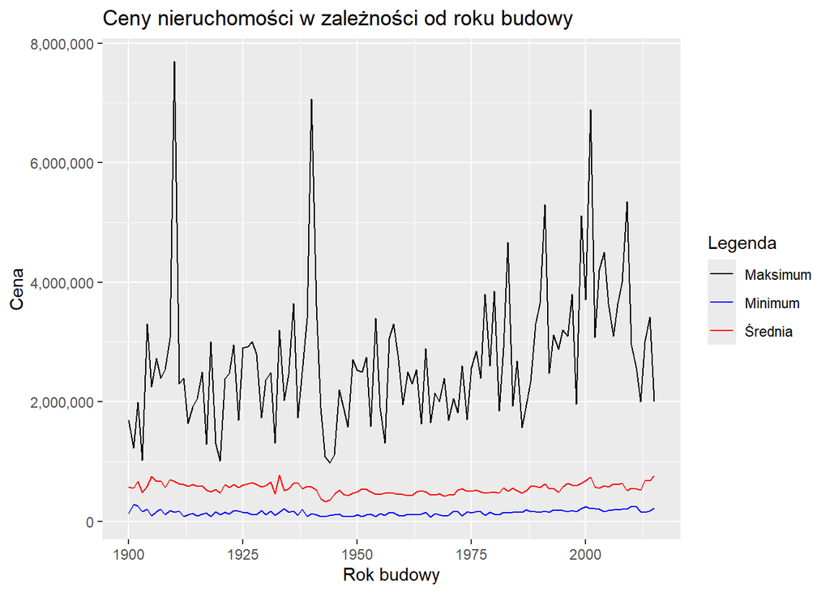

```r
# Tu umieść kod do wygenerowania odpowiedzi do zadania.

df %>%
  group_by(yr_built) %>%
  summarise(minimum = min(price), average = mean(price), maximum = max(price), .groups = 'drop') %>%
  ggplot(aes(x = yr_built))+
  geom_line(aes(y = average, color = "Średnia")) +
  geom_line(aes(y = minimum, color = "Minimum"))+
  geom_line(aes(y = maximum, color = "Maksimum")) +
  scale_color_manual(values = c("Średnia" = "red", "Minimum" = "blue", "Maksimum" = "black")) +
  scale_y_continuous(labels = scales::comma)+
  labs(title = "Ceny nieruchomości w zależności od roku budowy",
       color = "Legenda",
       x = "Rok budowy",
       y = "Cena")
```

**Komentarz: Na wykresie można zauważyć że średnia ceny nieruchomości i jej minimalna utrzymują się na zbliżonym poziomie i nie ma wśród nich tak gwałtownych zmian jak dla wartości maksymalnej. W latach 1940-1960 można zaobserwować niewielki spadek w średniej i minimalnej wartości, jednak jest on subtelny i mniej widoczny w porównaniu do dużych zmian wartości maksymalnej. Wartość maksymalna charakteryzuje się nieregularnymi skokami, z wyjątkowo wysokimi wartościami w latach 1910, 1940 i 2001, co sugeruje obecność wyjątkowo drogich nieruchomości wybudowanych w tych okresach.**